# Exercise 4

## 1 Constructing the Matrix

```python
import numpy as np
import scipy
from scipy.sparse import coo_matrix
from scipy.sparse.linalg import lsqr

def construct_X(M, alphas, Np=None):
    if Np is None:
        Np = int(np.sqrt(2) * M)

        if Np % 2 == 0:
            Np += 1

    alphas = np.asarray(alphas, dtype=float)

    D = M * M
    No = len(alphas)
    N = Np * No

    # Pixelcoordinates centered at (0, 0)
    coordinates = np.arange(M) - (M - 1) / 2
    a, b = np.meshgrid(coordinates, coordinates)

    # Form (2, D)
    C = np.vstack((a.ravel(), b.ravel()))

    pixel_indices = np.arange(D)

    all_rows = []
    all_columns = []
    all_weights = []

    sensor_center = (Np - 1) / 2

    for angle_index, alpha_deg in enumerate(alphas):
        alpha = np.deg2rad(alpha_deg)

        #correct convention cos, -sin
        n = np.array([np.cos(alpha), -np.sin(alpha)])

        # Sensorpositions for all Pixels
        p = n @ C + sensor_center

        left = np.floor(p).astype(int)
        right = left + 1

        fraction = p - left
        w_left = 1.0 - fraction
        w_right = fraction

        valid_left = (left >= 0) & (left < Np) & (w_left > 0)
        valid_right = (right >= 0) & (right < Np) & (w_right > 0)

        all_rows.append(left[valid_left] + angle_index * Np)
        all_columns.append(pixel_indices[valid_left])
        all_weights.append(w_left[valid_left])

        all_rows.append(right[valid_right] + angle_index * Np)
        all_columns.append(pixel_indices[valid_right])
        all_weights.append(w_right[valid_right])

    i_indices = np.concatenate(all_rows)
    j_indices = np.concatenate(all_columns)
    weights = np.concatenate(all_weights).astype(np.float32)

    X = coo_matrix(
        (weights, (i_indices, j_indices)),
        shape=(N, D),
        dtype=np.float32
    )

    return X
```

Comment

The matrix construction is largely correct and follows the same efficient strategy as the sample solution: all pixels are processed vectorially for each angle, the two interpolation weights are computed at once, and the non-zero entries are assembled as a `coo_matrix`. The coordinate ordering and the projection vector `[cos(alpha), -sin(alpha)]` are consistent with the reference matrix.

There is one issue in the default computation of `Np`: `int(np.sqrt(2) * M)` rounds down, whereas the exercise requires a sensor that is at least large enough for the image diagonal, i.e. `ceil(sqrt(2) * M)`. For some values of `M`, the current implementation can therefore choose a sensor that is too small. A possible fix is to use `np.ceil` before converting to `int`, and then make the result odd if necessary.

The separate masks `valid_left` and `valid_right` are a valid alternative to the sample solution's shared clipping mask. They also handle exact integer projections cleanly by omitting the zero-weight right entry.

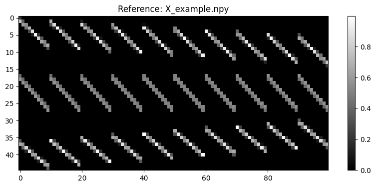

```python
import matplotlib.pyplot as plt

X_ref = np.load("hs_tomography/X_example.npy")

def show_matrix(X, title):
    if hasattr(X, "toarray"):
        X = X.toarray()
    plt.figure(figsize=(10, 4))
    plt.imshow(X, cmap="gray", aspect="auto")
    plt.title(title)
    plt.colorbar()
    plt.show()

show_matrix(X_ref, "Reference: X_example.npy")
```

### Visulaization of different Orientation

[figure not shown]

|  | convention | max_abs_diff | sum_abs_diff | mean_abs_diff | frobenius_norm | matches_reference |
| --- | --- | --- | --- | --- | --- | --- |
| 2 | [cos(alpha), -sin(alpha)] | 0.000000 | 0.000000 | 0.000000 | 0.000000 | True |
| 0 | [-cos(alpha), sin(alpha)] | 0.997805 | 529.595032 | 0.117688 | 17.990295 | False |
| 1 | [-cos(alpha), -sin(alpha)] | 0.997805 | 552.166809 | 0.122704 | 18.275146 | False |
| 3 | [cos(alpha), sin(alpha)] | 0.997805 | 377.515320 | 0.083892 | 15.314450 | False |

Comment

Loading and displaying `X_example.npy` is useful for checking the expected orientation. The additional comparison of several sign conventions is not required by the exercise, but it documents how the correct projection convention was identified. This is a valid debugging approach, although the large embedded table makes the notebook somewhat less concise.

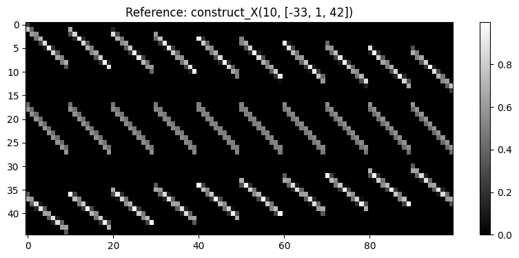

```
True
```

```python
X_test = construct_X(10, [-33, 1, 42]) # Test created function

show_matrix(X_test, "Reference: construct_X(10, [-33, 1, 42])")

### Compare against figure 2
comparison = np.allclose(X_ref, X_test.toarray())
comparison  # Constructed X is equivalent to the reference example
```

Comment

For `M = 10` and angles `[-33, 1, 42]`, the constructed matrix matches the provided reference exactly according to `np.allclose`. Thus, apart from the default-`Np` rounding issue described above, the implementation of task 1 is correct and is essentially equivalent to the vectorized sample solution.

## 2 Recovering the Image

```python
# Smaller one
a77 = np.load("hs_tomography/alphas_77.npy")
y77 = np.load("hs_tomography/y_77.npy")
X_small = construct_X(77, a77)

# Larger one
a195 = np.load("hs_tomography/alphas_195.npy")
y195 = np.load("hs_tomography/y_195.npy")
X_large = construct_X(195, a195)

# Exactly how many non-zero entries does X have? Use scipy's tools to and out and report the sparsity of X.
X_small_nnz = X_small.nnz
X_small_sparsity = (np.prod(X_small.shape) - X_small_nnz) / np.prod(X_small.shape)
print(f"X_small has {X_small_nnz} non-zero entries with {X_small_sparsity:.3f} sparsity")

X_large_nnz = X_large.nnz
X_large_sparsity = (np.prod(X_large.shape) - X_large_nnz) / np.prod(X_large.shape)
print(f"X_large has {X_large_nnz} non-zero entries with {X_large_sparsity:.3f} sparsity")

# Original image reconstruction
# X_77_reference = np.load("hs_tomography/X_77.npy", allow_pickle=True)
# X_77_reference = scipy.sparse.csc_matrix(X_77_reference.all())

small_image = lsqr(X_small, y77, atol=1e-07, btol = 1e-07)
large_image = lsqr(X_large, y195, atol=1e-07, btol = 1e-07)
# reference_image = lsqr(X_77_reference, y77, atol=1e-05, btol = 1e-05) # Dimension mismatch???
```

```
X_small has 1066978 non-zero entries with 0.982 sparsity
X_large has 13535933 non-zero entries with 0.993 sparsity
```

Comment

Construction of the X utilizing X_small is essentially equal to the sample solution. The sparsity ratio matches the small sparsity provided in the sample solution. When running the larger one the sparsity increases and matches the sample solution's ratio. The lsqr function is run in an equivalent way to the sample solution.

[figure not shown]

```python
# Plot small and large images
fig, (ax1, ax2) = plt.subplots(1, 2, figsize=(12, 6))
ax1.imshow(small_image[0].reshape(77,77), cmap="gray", aspect="equal")
ax2.imshow(large_image[0].reshape(195,195), cmap="gray", aspect="equal")
plt.show()
```

Diagnosis: H.S.'s headache is caused by having a crayon inside his brain. A treatment would be to not eat crayons or lodge them inside his cranial cavity lol.

Comment

Displaying of the image is essentially equal the sample solution's small and large example. The diagnosis being the crayon also matches the sample solution.

```python
a77 = np.load("hs_tomography/alphas_77.npy")
y77 = np.load("hs_tomography/y_77.npy")


X_small = construct_X(77, a77)

small_image = lsqr(X_small, y77, atol=1e-5, btol = 1e-5)


#print(a77)

data_size = y77.shape[0] // a77.shape[0]

different_sizes = 90

images = {}
errors = {}

highest_a = max(a77)
lowest_a = min(a77)

for i in range(1, different_sizes, 1):


    specific_a = [a77[int(a)] for a in list(np.linspace(0, len(a77)-1, num=i))]
    #specific_a.append(lowest_a)
    #specific_a.append(highest_a)
    #print(specific_a)

    #print([((int(np.where(a77 == a)[0][0])*data_size), ((int(np.where(a77 == a)[0][0])+1)*data_size))for a in specific_a])

    data_for_specific_a = np.array([y77[((int(np.where(a77 == a)[0][0]))*data_size):((int(np.where(a77 == a)[0][0])+1)*data_size)] for a in specific_a]).flatten()


    X_small = construct_X(77, specific_a)

    #print(data_for_specific_a)

    #print(y77.shape, a77.shape, X_small.shape, data_for_specific_a.shape, data_size)

    small_image_less_alpha = lsqr(X_small, data_for_specific_a, atol=1e-5, btol = 1e-5)


    error = ((((small_image[0] - small_image_less_alpha[0]))**2)**(1/2)).mean()

    print(len(specific_a), error)

    errors[len(specific_a)] = error
    images[len(specific_a)] = small_image_less_alpha
errors
```

```
1 49.65476373102797
2 44.30889583584475
3 40.854731043065996
4 37.61999278295518
5 36.257203971716635
6 33.53832218179639
7 33.70058487158799
8 32.180648619454374
9 30.866847611867872
10 30.025284180182396
11 29.474003974069717
12 28.790638080828604
13 28.13329732431186
14 27.123068422529645
15 26.873703434380737
```

[output cut: 74 more lines]

```
{1: 49.65476373102797,
 2: 44.30889583584475,
 3: 40.854731043065996,
 4: 37.61999278295518,
 5: 36.257203971716635,
 6: 33.53832218179639,
 7: 33.70058487158799,
 8: 32.180648619454374,
 9: 30.866847611867872,
 10: 30.025284180182396,
 11: 29.474003974069717,
 12: 28.790638080828604,
 13: 28.13329732431186,
 14: 27.123068422529645,
 15: 26.873703434380737,
```

[output cut: 74 more lines]

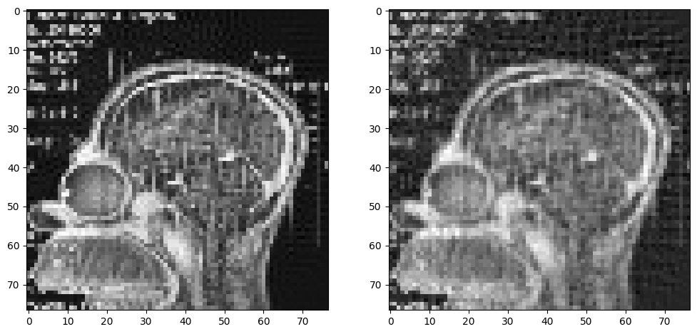

```python
fig, (ax1, ax2) = plt.subplots(1, 2, figsize=(12, 6))
ax1.imshow(small_image[0].reshape(77,77), cmap="gray", aspect="equal")
ax2.imshow(images[45][0].reshape(77,77), cmap="gray", aspect="equal")
plt.show()
```

```python
a195 = np.load("hs_tomography/alphas_195.npy")
y195 = np.load("hs_tomography/y_195.npy")
X_large = construct_X(195, a195)

large_image = lsqr(X_large, y195, atol=1e-5, btol = 1e-5)


#print(a77)

data_size = y195.shape[0] // a195.shape[0]

different_sizes = 180

images_large = {}
errors_large = {}

highest_a = max(a195)
lowest_a = min(a195)

for i in range(1, different_sizes, 1):


    specific_a = [a195[int(a)] for a in list(np.linspace(0, (len(a195))-1, num=i))]
    #specific_a.append(lowest_a)
    #specific_a.append(highest_a)
    #print(specific_a)

    #print([((int(np.where(a77 == a)[0][0])*data_size), ((int(np.where(a77 == a)[0][0])+1)*data_size))for a in specific_a])

    data_for_specific_a = np.array([y195[((int(np.where(a195 == a)[0][0]))*data_size):((int(np.where(a195 == a)[0][0])+1)*data_size)] for a in specific_a]).flatten()


    X_large = construct_X(195, specific_a)

    #print(data_for_specific_a)

    #print(y195.shape, a195.shape, X_large.shape, data_for_specific_a.shape, data_size)

    large_image_less_alpha = lsqr(X_large, data_for_specific_a, atol=1e-5, btol = 1e-5)


    error = ((((large_image[0] - large_image_less_alpha[0]))**2)**(1/2)).mean()

    print(len(specific_a), error)

    errors_large[len(specific_a)] = error
    images_large[len(specific_a)] = large_image_less_alpha
errors_large
```

```
1 36.45652751416388
2 32.09105747961617
3 28.745058303972183
4 27.42815571820321
5 26.43866162989189
6 25.04241110255268
7 24.499017203073734
8 24.047937276935425
9 23.61044194174914
10 23.092249778175702
11 22.729763256587145
12 22.231728028881612
13 21.982741441737904
14 21.715862106096857
15 21.457678610663937
```

[output cut: 74 more lines]

```
{1: 36.45652751416388,
 2: 32.09105747961617,
 3: 28.745058303972183,
 4: 27.42815571820321,
 5: 26.43866162989189,
 6: 25.04241110255268,
 7: 24.499017203073734,
 8: 24.047937276935425,
 9: 23.61044194174914,
 10: 23.092249778175702,
 11: 22.729763256587145,
 12: 22.231728028881612,
 13: 21.982741441737904,
 14: 21.715862106096857,
 15: 21.457678610663937,
```

[output cut: 74 more lines]

[figure not shown]

```python
fig, (ax1, ax2) = plt.subplots(1, 2, figsize=(12, 6))
ax1.imshow(large_image[0].reshape(195, 195), cmap="gray", aspect="equal")
ax2.imshow(images_large[89][0].reshape(195, 195), cmap="gray", aspect="equal")
plt.show()
```